```python
import numpy as np
import pandas as pd
import matplotlib.pyplot as plt
import seaborn as sns

file = 'titanic_data.csv'
titanic_df = pd.read_csv(file)

# add new columns
# FamSize = total number of people traveling together
titanic_df['FamSize'] = pd.Series(titanic_df['SibSp']+titanic_df['Parch'], index=titanic_df.index)

# Survivor converts numeric value in survived to text label
# example from http://stackoverflow.com/questions/17702272/convert-pandas-series-containing-string-to-boolean
d = {0:'Died', 1:"Survived"}
titanic_df['Survivor'] = pd.Series(titanic_df['Survived'].map(d), index=titanic_df.index)
c = {1:'First Class', 2:'Second Class', 3:'Third Class'}
titanic_df['Classes']= pd.Series(titanic_df['Pclass'].map(c), index=titanic_df.index)

%pylab inline
#print titanic_df.head(10)
print '\n Summary Info on Titanic Data \n',titanic_df.info()
print '\n Descriptive Statistics on Titanic Data \n', titanic_df.describe()
```

```
 Summary Info on Titanic Data
<class 'pandas.core.frame.DataFrame'>
Int64Index: 891 entries, 0 to 890
Data columns (total 15 columns):
PassengerId    891 non-null int64
Survived       891 non-null int64
Pclass         891 non-null int64
Name           891 non-null object
Sex            891 non-null object
Age            714 non-null float64
SibSp          891 non-null int64
Parch          891 non-null int64
Ticket         891 non-null object
Fare           891 non-null float64
Cabin          204 non-null object
Embarked       889 non-null object
FamSize        891 non-null int64
Survivor       891 non-null object
Classes        891 non-null object
dtypes: float64(2), int64(6), object(7)
memory usage: 111.4+ KB
None

 Descriptive Statistics on Titanic Data
       PassengerId    Survived      Pclass         Age       SibSp  \
count   891.000000  891.000000  891.000000  714.000000  891.000000
mean    446.000000    0.383838    2.308642   29.699118    0.523008
std     257.353842    0.486592    0.836071   14.526497    1.102743
min       1.000000    0.000000    1.000000    0.420000    0.000000
25%     223.500000    0.000000    2.000000   20.125000    0.000000
50%     446.000000    0.000000    3.000000   28.000000    0.000000
75%     668.500000    1.000000    3.000000   38.000000    1.000000
max     891.000000    1.000000    3.000000   80.000000    8.000000

            Parch        Fare     FamSize
count  891.000000  891.000000  891.000000
mean     0.381594   32.204208    0.904602
std      0.806057   49.693429    1.613459
min      0.000000    0.000000    0.000000
25%      0.000000    7.910400    0.000000
50%      0.000000   14.454200    0.000000
75%      0.000000   31.000000    1.000000
max      6.000000  512.329200   10.000000
```

# 0. Introduction and Tentative Findings

For this analysis, we were supplied a set of data from the Titanic disaster. The dataset contains demographics and passenger information from 891 of the 2224 passengers and crew on board the Titanic. For this analysis, we will assume this data is a representative sample of the population of the Titanic passengers.

In short, this analysis will show the following factors *may have* increased the odds of survival.

- Female
- First class passengers
- Traveling with 1-3 members of the same family

# 1. How did gender affect survival rates on the Titanic?

Surviors were more than twice as likely to be female. Female survivors (233 or 68%) far outnumbered male suvivors (109 or 32%). This is represented in the pie chart below.

However, if there were more female passengers than male, this could cloud the findings. Additional analysis is needed. We should also look at survival rates for male and female passengers. This is explored in question 2.

```
 Number of survivors
Sex
female    233
male      109
Name: Survived, dtype: int64
```

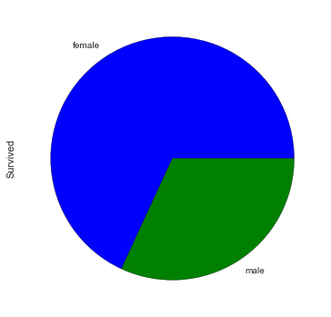

```python
df0 = titanic_df.groupby(['Sex']).sum()['Survived']
print '\n Number of survivors \n', df0
df0.plot(kind='pie', figsize = (6,6))

# example from http://pandas.pydata.org/pandas-docs/stable/visualization.html#visualization-pie
```

# 2. How did gender affect survival rates on the Titanic? (v2)

In this summarization, we see that females were about 3 times more likely to survive than not. 74% (233) of all females survived the disaster, but only 26% (81) of females perished. In contrast, males were 4 times more likely to perish. 81% (468) of the males perished and only 19% (109) survived.

```python
df1 = titanic_df.groupby(['Sex', 'Survivor']).count()['PassengerId']
print '\n Number of survivors by gender \n', df1

df1a = titanic_df.groupby('Sex')['Survived'].mean()
print '\n Proportion of survivors by gender \n', df1a


#df1.plot(kind='pie', figsize = (6,6))
#chart produced is not helpful
# example from http://pandas.pydata.org/pandas-docs/stable/visualization.html#visualization-pie
```

```
 Number of survivors by gender
Sex     Survivor
female  Died         81
        Survived    233
male    Died        468
        Survived    109
Name: PassengerId, dtype: int64

 Proportion of survivors by gender
Sex
female    0.742038
male      0.188908
Name: Survived, dtype: float64
```

# 3. How did passenger class affect survival rates on the Titanic?

The following bar graphs indicate that being a third class passenger, and specifically a male third class passenger, seem to have had a negative impact on survival rates. 76% (372) of third class passengers perished. 300 of the third class passengers were male. This is in stark contrast to first class survival rates where 63% (136) of passengers survived. 97% (91) of female first class passengers survived.

```
 Number of survivors by Passenger class
Classes       Survivor
First Class   Died         80
              Survived    136
Second Class  Died         97
              Survived     87
Third Class   Died        372
              Survived    119
Name: PassengerId, dtype: int64

 Proportion of survivors by Passenger class
Classes
First Class     0.629630
Second Class    0.472826
Third Class     0.242363
Name: Survived, dtype: float64

 Number of survivors by Passenger class and gender
Classes       Survivor  Sex
First Class   Died      female      3
                        male       77
              Survived  female     91
                        male       45
Second Class  Died      female      6
                        male       91
              Survived  female     70
                        male       17
Third Class   Died      female     72
                        male      300
              Survived  female     72
                        male       47
Name: PassengerId, dtype: int64

 Proportion of survivors by Passenger class and gender
Classes       Sex
First Class   female    0.968085
              male      0.368852
Second Class  female    0.921053
              male      0.157407
Third Class   female    0.500000
              male      0.135447
Name: Survived, dtype: float64
```

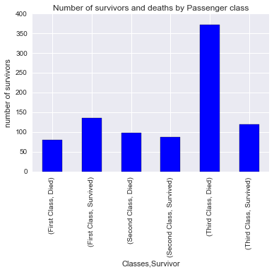

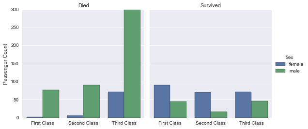

```python
df2 = titanic_df.groupby(['Classes', 'Survivor']).count()['PassengerId']
print '\n Number of survivors by Passenger class \n', df2
ax = df2.plot(kind='bar', title='Number of survivors and deaths by Passenger class')
ax.set_ylabel("number of survivors")

df2a = titanic_df.groupby(['Classes'])['Survived'].mean()
print '\n Proportion of survivors by Passenger class \n', df2a

# from instructor feedback on first submission
# summarize the dataframe by grouping across 3 columns and counting names
t = titanic_df.groupby(['Pclass', 'Sex', 'Survivor'], as_index = False)['Name'].count()
#print t
# plot categorical variables as appropriate
p = sns.factorplot(data = t, x = 'Pclass', y = 'Name', col = 'Survivor', hue = 'Sex', kind = 'bar')
(p.set_axis_labels('', 'Passenger Count')
  .set_xticklabels(['First Class', 'Second Class', 'Third Class'])
  .set_titles("{col_name}"))

df2b = titanic_df.groupby(['Classes', 'Survivor', 'Sex']).count()['PassengerId']
print '\n Number of survivors by Passenger class and gender \n', df2b

df2c = titanic_df.groupby(['Classes','Sex'])['Survived'].mean()
print '\n Proportion of survivors by Passenger class and gender \n', df2c
```

# 4. How did family size affect survival rates on the Titanic?

Lastly, it appears that family size may have impacted survival rates. Passengers traveling alone or traveling with a family size of 4 or larger seems to have had a negative impact on survival rates. The survival rates exceeded the death rates only in cases where the passengers were traveling with 1, 2, or 3 family members.

```
FamSize  Survivor
0        Died        374
         Survived    163
1        Died         72
         Survived     89
2        Died         43
         Survived     59
3        Died          8
         Survived     21
4        Died         12
         Survived      3
5        Died         19
         Survived      3
6        Died          8
         Survived      4
7        Died          6
10       Died          7
Name: PassengerId, dtype: int64
```

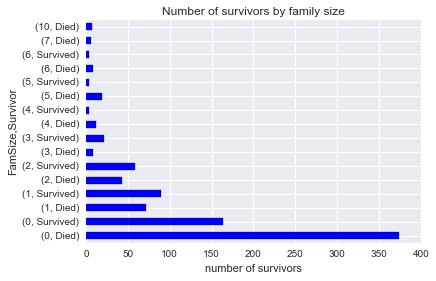

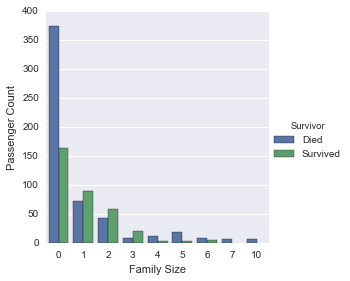

```python
df3 =  titanic_df.groupby(['FamSize', 'Survivor']).count()['PassengerId']
print df3
ax = df3.plot(kind='barh', title='Number of survivors by family size')
ax.set_xlabel("number of survivors")

# from instructor feedback after first submission
df3a = titanic_df.groupby(['FamSize', 'Survivor'], as_index = False)['Name'].count()
#print df3a
p2 = sns.factorplot(data = df3a, x = 'FamSize', y = 'Name', hue = 'Survivor', kind = 'bar')
(p2.set_axis_labels('Family Size', 'Passenger Count'))
```

# 5. Limitations of the Analysis

This analysis is limited by several factors, including the following:

*Missing values:* Age and Cabin contained missing values and are not included in this analysis. In particular, Cabin would have been an interesting analysis to see the relation to survival rates. It is very possible the survival rates were higher on the upper decks. However, only 204 of the 891 records contained the passenger cabin. Age and survival rate would have been another interesting analysis. But a decision would need to be made on how to handle the missing values. For age, I would simply drop the rows with missing values since a good amount of data still exists. This seems to have the least impact on mean, etc. for Age. However, this could be skewing the data in other columns. Trade-offs exist in any method chosen to handle missing data, and these should be considered carefully.

*Calculations vs Statistical Tests:* Interesting summary statistics should not be interpreted as "statistically significant". We can reasonably assume some of the largest differences in survival rates are also statistically significant. However, a more robust analysis would utitlize appropriate statistical tests to validate these findings and uncover insights for smaller differences in survival rates.

*Representative sample:* For this analysis, we will assume this dataset is a representative sample of the population of the Titanic passengers and crew. This may not be the case. There is also the possibility of outside factors that may have influenced survival rates, such as the amount time spent in the water.